# Econ_hw_3

Sarah Rohlfing, Meghna Rao, Alessandra Puig-Santana

5/2/2022

## Question 1

- 1 kwh = 0.85 lbs CO2 emitted
- $51/metric ton CO2 emitted = SCC
- $51/metric ton of CO2 emitted = $51/2204.62 lbs of CO2 emitted = $0.023/lbs
- $0.023/lbs * 0.85 lbs CO2 emitted = $0.01955
- *MEC per kwh of electricity is $0.01955*

## Question 2

### Demand for Low Income Group

- P1 = (m1)*(Q1) + (b1)
- P1 = (-0.00011)(Q1) + 23.37097
- Q1 = (P1 - b1)/(m1)
- Q1 = (P1 - 23.4)/(-0.00011)

### Aggregate Demand

- Horizontally sum demand for low income and high income groups
- determine slope of the line (magg) using “rise over run” = -0.000035336
- determine the intercept (bagg) = 28.96543
- Pagg = -0.000035336*Qagg + 28.96543

```
## (Intercept)
##    536719.5
```

```
## (Intercept)
##    763114.9
```

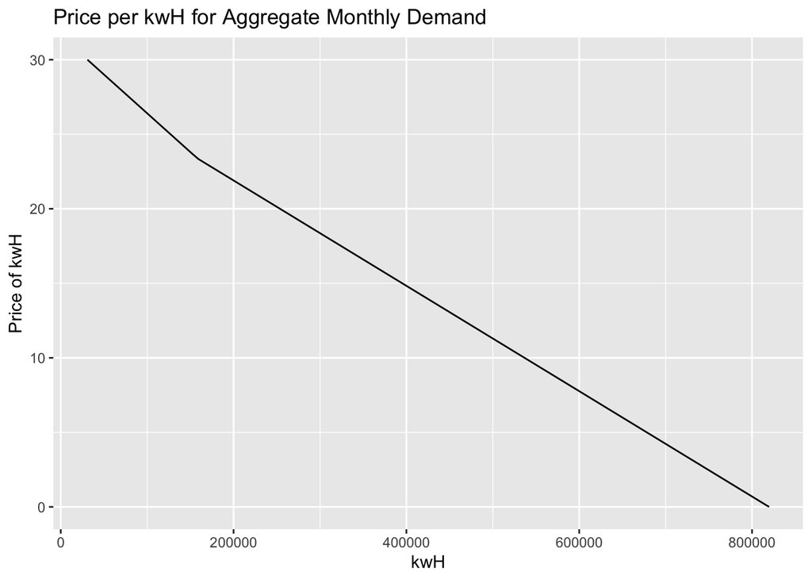

### Supply Curve

- Current electricity price is $0.10
- Supply curve will intersect aggregate demand curve at the current electricity price
- When Pagg = 10, Qagg = 536,719.5
- The marginal cost (MPC) of producing a kWh of electricity is linear and has a price-intercept of 0. Thus Pmpc = 0 when Qmpc = 0
- MPC_slope = (0 - 10)/(0 - 536719.5) = 0.00001863171
- Pmpc = MPC_slope*Q
- Pmpc = 0.00001863171*Q

[figure not shown]

### Consumer Benefit under the Status Quo

- Consumer surplus for all consumers is $52,987.22. This is the area under the aggregate demand curve until the intersection of the supply and aggregate demand curves.

### Producer Benefit under the Status Quo

- Producer surplus is $26,835.97. This is the area above the supply curve until the intersection of the supply and aggregate demand curves

### Environmental Cost under Status Quo

- Environmental cost is $10,734.39.

## Question 3

### Consumer benefit for low v high income consumers

- Consumer surplus for only low income consumers is $8,112
- Consumer surplus for only high income consumers is $44,875
- Consumers with a higher income have $36,763 greater consumer surplus than consumers with a lower income

## Question 5:

1. Overall welfare of “high” income consumers:
- at SCC of *$51* per metric ton of carbon: high income consumer welfare is *$37,171*
- at SCC of *$75* per metric ton of carbon: high income consumer welfare is *$33,801*
- at SCC of *$100* per metric ton of carbon: high income consumer welfare is *$30,426*
- at SCC of *$125* per metric ton of carbon: high income consumer welfare is *$27,304*
- at SCC of *$150* per metric ton of carbon: high income consumer welfare is *$24,321*
2. Overall welfare of “low” income consumers
- at SCC of *$51* per metric ton of carbon: low income consumer welfare is *$7,075*
- at SCC of *$75* per metric ton of carbon: low income consumer welfare is *$7,056*
- at SCC of *$100* per metric ton of carbon: low income consumer welfare is *$7,036*
- at SCC of *$125* per metric ton of carbon: low income consumer welfare is *$7,016*
- at SCC of *$150* per metric ton of carbon: low income consumer welfare is *$6,997*
3. Electricity producers surplus
- at SCC of *$51* per metric ton of carbon: producer welfare is *$25,081*
- at SCC of *$75* per metric ton of carbon: producer welfare is *$24,276*
- at SCC of *$100* per metric ton of carbon: producer welfare is *$23,451*
- at SCC of *$125* per metric ton of carbon: producer welfare is *$22,640*
- at SCC of *$150* per metric ton of carbon: producer welfare is *$21,844*

## Question 6

1. Total electricity consumption is 313,692 kwh
2. The total environmental externality cost is $8,256
3. The value of the electricity tax that makes the total environmental damage the same as the damage when solar panels are available to the high income group is $0.0314